# Lab 3 - Clustering Analysis

### Citations are represented with prefix şş followed by reference link.

Authors: Huy Hoang Nguyen, Sanjay Pillay, Hao Wang, Wailun Chung  
(Southern Methodist University - USA)

## Table of Contents:

### 1. Introduction and Business Understanding

### 2. Data Understanting - Part I

### 3. Data Understanting - Part II

### 4. Modeling and Evaluation 1

### 5. Modeling and Evaluation 2

### 6. Modeling and Evaluation 3

### 7. Modeling and Evaluation 4

### 8. Deployment

### 9. Exceptional Work

# 1. Introduction and Business Understanding

## Introduction

In this lab, we will use different machine learning algorithms to implement clustering as a feature selection technique. We will compare a few of our existing models from [Lab 2](https://hnguye01.github.io/DS7331/lab2.html) to see if clustering provides any advantage on those models.

For the the regression models that predicted player wages, we make an assumption that the super star players, average players, new players, or other types of players can make a big influence on the players' wage. Therefore, there maybe outliers that may affect the accuracy of the regression models. A superstar player usually get extremely high wages and we believe the key feature to identify those players are the attacking skill features. We will implement clustering to find the potential groups from the attacking features. Then, we will use the clustered result combining with rest of the features to run regression tests.

We will be using MAE for the comparison. MAE measures the average magnitude of the errors in a set of predictions without considering their direction. It takes the average over the test sample of the absolute differences between prediction and actual observation where all individual differences have equal weight.  
We carry over the Business Understanding and Data Preparation from Lab 2. More information related to Visualization and Data Preprocessing can be found in Lab 2.

## Business Understanding

Kaggle dataset (https://www.kaggle.com/stefanoleone992/fifa-20-complete-player-dataset) *players_20.csv* is used in this lab. The dataset provides detailed information of all the **soccer players statistics** in various clubs of major soccer leagues in the world. The data is originally from the FIFA soccer game created by EA sports. This game estimates the abilities of the actual players and built the game according to the data. And the Kaggle dataset is scraped from www.sofifa.com, where the gaming data is collected. The data we used is last updated on Sept 19th 2019.

The dataset is important because the abilities of players is estimated from the actual players. FIFA is a very popular game and EA Sports is one of the largest sport video game developer. The player abilities estimate is quite accurate. Therefore, useful knowledge can be mined from the data for analyzing variety problems in the soccer industry. For example, wage analysis, player analysis, training strategy, budget analysis, sport gambling strategy plan can be performed using this dataset. Soccer has been a big industry which the market size is estimated to worth $488 billion in 2018 according to the Business Wire.

⏫ Table of Contents

# 2. Data Understanding I

In this subsection, we deal with missing values, converting data types to appropriate ones. We will also divide the soccers players into 4 groups meaningfully as Defending (DEF), Forward (FWD), Midfield (MID) and Goal Keeper (GK) to learn from existing dataset to predict new players potential positions based on their skillset. We will come with our final cleaned dataset for our regression and classification task's.

Note: We will reserve the data scaling to Part 2 subsection while preparing the test/train dataset.

```python
#All Python module imports
#https://pandas.pydata.org/docs/user_guide/index.html#user-guide
import pandas as pd #Pandas Dataframe module

import numpy as np
from math import pi
#scikit learn
#https://scikit-learn.org/stable/modules/classes.html#module-sklearn.linear_model
import sklearn as sl


import pycountry
import plotly.express as px

#https://seaborn.pydata.org
import seaborn as sns
import matplotlib.pyplot as plt

# os calls
import os

#Module for formating table for documentation
#https://pypi.org/project/tabulate/
from tabulate import tabulate

from IPython.display import display, Markdown

#Interactive mode
from IPython.core.interactiveshell import InteractiveShell
InteractiveShell.ast_node_interactivity = "all"
from IPython.display import Image

##minilab imports
from sklearn.model_selection import GridSearchCV as gridcv
from sklearn import preprocessing
from sklearn.feature_selection import SelectKBest, chi2
from sklearn.model_selection import StratifiedShuffleSplit
from sklearn.preprocessing import StandardScaler
from sklearn.linear_model import LogisticRegression
from sklearn import metrics as mt
from sklearn.metrics import plot_confusion_matrix
from sklearn.metrics import classification_report
from sklearn.svm import SVC
from sklearn.decomposition import PCA
from sklearn.metrics import confusion_matrix
from sklearn.metrics import f1_score, accuracy_score
```

Due to the large number of features we have created a csv file that will serve as a metadata file as follows  
1) File location: ../data/fifa20/data_desc.csv  
2) The Name column as the exact name that is in our original dataset file and we will use this to load the file.  
3) Description: The team has filled up the description of each feature describing it.  
4) Variable_cat: We use this to categorise related features for example 'Position' indicates all the features related to various position attirbutes.  
Using a metadata makes it easy in case we want to ignore certain attributes that are not relavant for our analysis by marking it as Ignore.

```python
##Globally set seed
np.random.seed(45)

#Read data explanation csv file maintained by project team
%time df_desc = pd.read_csv('../data/fifa20/data_desc.csv',usecols=['Name','Description','Statistics','Variable_cat'])
#display(Markdown(df_desc[['Name','Description','Variable_cat']].to_markdown()))

#All positional attributes, These are various field positions a players can playin with a players statisics in
#that position. These attributes are only for non-goalkeepers.
df_position_attr = df_desc[df_desc['Variable_cat']=='Position']['Name']

#All goalKeeper only attributes
df_gk_attr = df_desc[df_desc['Variable_cat']=='GK']['Name']

#All Technical attributes. Non GK players primary technical skills such as dribbling, curving etc.
df_technical_attr = df_desc[df_desc['Variable_cat']=='Technical']['Name']

#All mental attributes for all players
df_mental_attr = df_desc[df_desc['Variable_cat']=='Mental']['Name']

#All Attacking attributes  for all players
df_attacking_attr = df_desc[df_desc['Variable_cat']=='Attacking']['Name']

#All general Skill category attributes  for all players
df_skill_attr = df_desc[df_desc['Variable_cat']=='Skill']['Name']

#All Movement attributes  for all players
df_movement_attr = df_desc[df_desc['Variable_cat']=='Movement']['Name']

#All Power attributes  for all players
df_power_attr = df_desc[df_desc['Variable_cat']=='Power']['Name']

#All Defending attributes  for all players
df_defending_attr = df_desc[df_desc['Variable_cat']=='Defending']['Name']

# Sample code for future use to include adhoc columns
# Get all columns of player posiotion, you can do same for technical, Physical, GK etc
## l=df_gk_attr.append(pd.Series(['short_name','age','club']))
## df_gkplus_list from main object df_players = df_players[l]
```

```
CPU times: user 2.31 ms, sys: 1.03 ms, total: 3.33 ms
Wall time: 3.52 ms
```

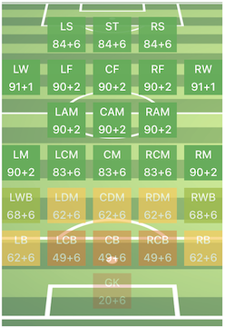

This image helps us understand various positions that a soccer players is assigned during a game. The feature **player_positions** represents multiple positions that a player can play in with a comma seperate value, the very first item in that list has a preferred field position of the player. The **team_position** is the current positon that the player is being used in the team. For our analysis we will use the players preferred positon.

```python
#Data mining read csv file
#Using data set: https://www.kaggle.com/stefanoleone992/fifa-20-complete-player-dataset#players_15.csv
#we will read only data we are intrested in
cols_to_read = df_desc['Name'].loc[df_desc.Variable_cat != 'Ignore']
%time df_players = pd.read_csv('../data/fifa20/players_20.csv',usecols=cols_to_read)
```

```
CPU times: user 153 ms, sys: 31.5 ms, total: 185 ms
Wall time: 192 ms
```

The feature player_positions has the comma seperated list of a players prefered positions in order of their most prefered one being first. We will use the first position as the players position for our analysis and introduce a new column to hold this.

```python
df_players['preferred_position'] = df_players.player_positions.str.split(',').apply(lambda x: x[0])
```

#### team_postion

We see the team_position has 241 empty values. Since we do not intent to use team_position nor nation_positon in our analysis, we will drop it.

```python
df_players = df_players.drop(columns=['nation_position','team_position'])
```

#### Wages

As seen on analysis in the above section, there are 240 players with 0 wages_eur and 250 with with 0 value_eur, we will fill these with median values for our predictions.

```python
# 1. wages, The fields wage_eur and value_eur have about 240 and 250 vales respectively set to 0 (Analyzed in
# section B), we will set these values to the respective median values
#df_players['wage_eur'].median()
df_players['wage_eur'].replace(0,df_players['wage_eur'].median(), inplace=True)
```

```python
#df_players['value_eur'].median()
df_players['value_eur'].replace(0,df_players['value_eur'].median(), inplace=True)
df_players.shape
```

```
(18278, 86)
```

```python
df_players['wage_eur'].value_counts(bins=7)
```

```
(435.999, 81571.429]        18034
(81571.429, 162142.857]       176
(162142.857, 242714.286]       47
(242714.286, 323285.714]       13
(323285.714, 403857.143]        5
(403857.143, 484428.571]        2
(484428.571, 565000.0]          1
Name: wage_eur, dtype: int64
```

We will remove three outliner records who are paid extremly high (This analysis was done in Lab1). We chose to do this to avoid fitting our model to this outliners in regression.

```python
df_players.drop(df_players[df_players['wage_eur'] > 400000].index, inplace = True)
df_players = df_players.reset_index()
df_players.shape
```

```
(18275, 87)
```

#### Body type

```python
df_players['body_type'].replace({'Shaqiri': 'Normal', 'Akinfenwa': 'Normal'
                                , 'C. Ronaldo': 'Normal', 'PLAYER_BODY_TYPE_25': 'Normal'
                                , 'Neymar': 'Normal', 'Courtois': 'Normal','Messi':'Normal'}, inplace=True)
#df_players['body_type'].value_counts()
```

#### Refactor position features [Object to discrete]

The position features inculdes year over improvement / decrement. For example a player in st (Striker) position with a value of 89+2 is basically 89 with an increase (- would indicate decrease) of 2 from last year. Since we will not be doing any year over analysis, we will remove the suffix for these columns = ['ls','st','rs','lw','lf','cf','rf', 'rw','lam','cam','ram', 'lm','lcm','cm','rcm','rm','lwb','ldm', 'cdm','rdm', 'rwb','lb','lcb', 'cb','rcb','rb']

```python
# 4. Refactor position features based on bullet 1 above to remove the +/- incriment/decriment and preseve
# the current years score
df_players1 = df_players[df_position_attr].apply(lambda x: x.str.slice(start=0,stop=2),
                          axis=1, result_type='broadcast')
df_players[df_position_attr] = df_players1
```

#### Dealing with missing values

The player positional features mentioned above and the skills features ['pace','shooting', 'passing','dribbling', 'defending','physic'] have a total of 2036 missing values. We see that all of them are categorized to play in the GK position (player_positions="GK", Goal Keeper). We will set these values to zero.

#### Goal Keeper specific attributes

The following features ['gk_diving','gk_handling','gk_kicking','gk_reflexes', 'gk_speed','gk_positioning'] are specific to goalkeepers. We see a total of 16242 mising values, which corrosponds to the non goalkeeper or regular positional players. We will set these values to zero. Also there are duplicate columns representing these same attributes which we will ignore ['goalkeeping_diving', 'goalkeeping_handling', 'goalkeeping_kicking', 'goalkeeping_positioning', 'goalkeeping_reflexes']

```python
df_players.info(verbose=True, null_counts=True)
```

```
<class 'pandas.core.frame.DataFrame'>
RangeIndex: 18275 entries, 0 to 18274
Data columns (total 87 columns):
 #   Column                      Non-Null Count  Dtype
---  ------                      --------------  -----
 0   index                       18275 non-null  int64
 1   sofifa_id                   18275 non-null  int64
 2   short_name                  18275 non-null  object
 3   age                         18275 non-null  int64
 4   dob                         18275 non-null  object
 5   height_cm                   18275 non-null  int64
 6   weight_kg                   18275 non-null  int64
 7   nationality                 18275 non-null  object
 8   club                        18275 non-null  object
 9   overall                     18275 non-null  int64
```

[output cut: 79 more lines]

```python
# 5, 6. we will set all the other missing variables to 0 as explained above in bullet 4 & 5
df_players.fillna(0, inplace=True)
```

#### Data type conversion

We will first convert our continuous features.

```python
# changing the continuous values to be float64
continuous_features = ['height_cm','weight_kg','value_eur', 'wage_eur']
df_players[continuous_features] = df_players[continuous_features].astype(np.float64)
```

sofifa_id is converted to object as it is a nominal

```python
df_players['sofifa_id'] = df_players['sofifa_id'].astype(np.object)
```

We will convert object features that are discrete to integer

```python
#change the position features from object to int64 as they we manipulated to remove +/- based on step 1
df_players[df_position_attr] = df_players[df_position_attr].astype(np.int64)
#df_players.info(verbose=True, null_counts=True)
```

#### Onehot Encoding positions

As we will be using the players prefered position for the regression modles to predict players wages we will one hot encode the position. We will drop one of the columns of the encoded set.

```python
from sklearn.preprocessing import OneHotEncoder

# we will create the encoder and drop the first column
enc = OneHotEncoder(handle_unknown='error', drop='first').fit(df_players[['preferred_position']])
df_players.shape
enc.categories_
X = enc.transform(df_players[['preferred_position']]).toarray()
X.shape
#Check the categories
enc.inverse_transform([[0, 0, 0, 0, 0,0,0,0,0,0,0,0,0,0]])

## Add back to df
p = pd.DataFrame(X)
p.shape
## We will use this dataframe later to add it to the regression classification set
```

```
(18275, 87)
```

```
[array(['CAM', 'CB', 'CDM', 'CF', 'CM', 'GK', 'LB', 'LM', 'LW', 'LWB',
        'RB', 'RM', 'RW', 'RWB', 'ST'], dtype=object)]
```

```
(18275, 14)
```

```
array([['CAM']], dtype=object)
```

```
(18275, 14)
```

```python
df_players.info(verbose=True, null_counts=True)
```

```
<class 'pandas.core.frame.DataFrame'>
RangeIndex: 18275 entries, 0 to 18274
Data columns (total 87 columns):
 #   Column                      Non-Null Count  Dtype
---  ------                      --------------  -----
 0   index                       18275 non-null  int64
 1   sofifa_id                   18275 non-null  object
 2   short_name                  18275 non-null  object
 3   age                         18275 non-null  int64
 4   dob                         18275 non-null  object
 5   height_cm                   18275 non-null  float64
 6   weight_kg                   18275 non-null  float64
 7   nationality                 18275 non-null  object
 8   club                        18275 non-null  object
 9   overall                     18275 non-null  int64
```

[output cut: 79 more lines]

⏫ Table of Contents

# 3. Data Understanding 2

## Visualize Attributes

### Wages by position

In the box plot below we see the median wage for a player in center forward is the highest and the distribution for CF for value is larger too. The players with left foot are paid more on average in some positions. For example "RW", "RM", "LWB", where as in "CF", "RB" it is the opposite. We are not sure the reasoning.

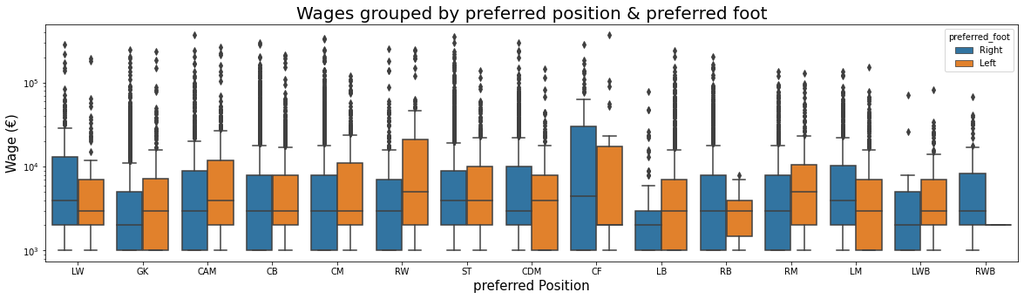

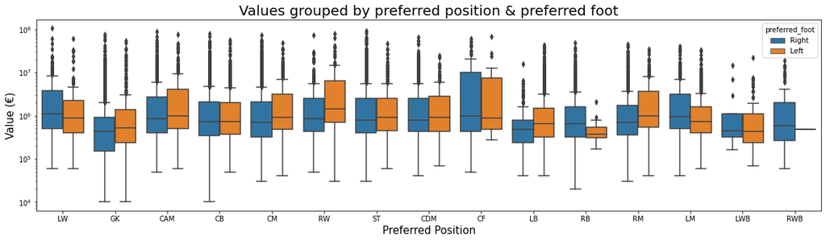

```python
#Plotting wages distribution on log scale by position
plt.figure(figsize=(20,5))
ax = sns.boxplot(data=df_players, y='wage_eur', x='preferred_position', hue='preferred_foot');
ax.set_yscale('log');
ax.set_title('Wages grouped by preferred position & preferred foot', fontsize=20);
ax.set_xlabel('preferred Position', fontsize=15);
ax.set_ylabel('Wage (€)', fontsize=15);

# plotting values distribution with sns
plt.figure(figsize=(20,5));
ax1 = sns.boxplot(data=df_players, y='value_eur', x='preferred_position', hue='preferred_foot');
ax1.set_yscale('log');
ax1.set_title('Values grouped by preferred position & preferred foot', fontsize=20);
ax1.set_xlabel('Preferred Position', fontsize=15);
ax1.set_ylabel('Value (€)', fontsize=15);

#df_players['wage_eur'].describe()
```

### Statistics on player height in various positions

Goal keepers and center back on average are taller than other players.

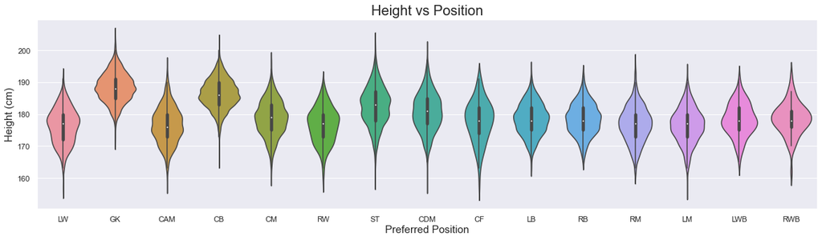

```python
plt.figure(figsize=(20,5));
sns.set();
ax_height = sns.violinplot(y=df_players['height_cm'], x=df_players['preferred_position'], dodge=True);

ax_height.set_title('Height vs Position', fontsize=20);
ax_height.set_xlabel('Preferred Position', fontsize=15);
ax_height.set_ylabel('Height (cm)', fontsize=15);
```

### Statistics on player weight in various positions

Right and Left wing players on average are lighter than other players. The reason could be the wing players often need to run back and forth to the goalline.

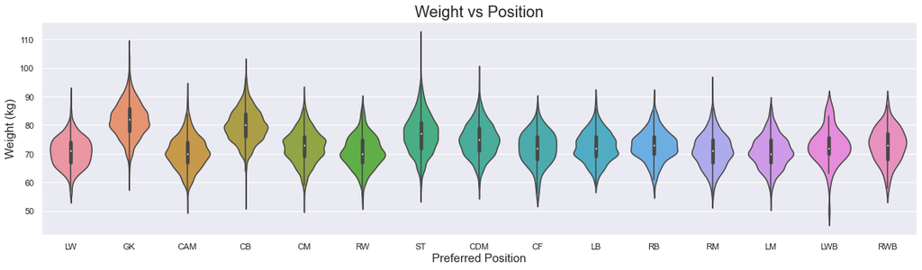

```python
plt.figure(figsize=(20,5));
sns.set();
ax_weight = sns.violinplot(y=df_players['weight_kg'], x=df_players['preferred_position'], dodge=True);

ax_weight.set_title('Weight vs Position', fontsize=20);
ax_weight.set_xlabel('Preferred Position', fontsize=15);
ax_weight.set_ylabel('Weight (kg)', fontsize=15);
```

### Average rating by age (Potential, Overall and Age)

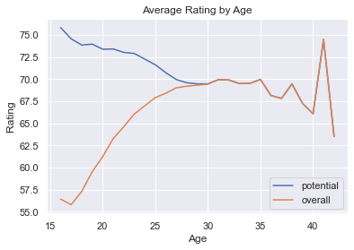

```python
# Our cleaned dataset **copy** is df_players_cleaned
df_players_cleaned = df_players.copy()
df_players_cleaned.shape

df_players_cleaned_p = df_players_cleaned.groupby(['age'])['potential'].mean()
df_players_cleaned_o = df_players_cleaned.groupby(['age'])['overall'].mean()
df_players_cleaned_summary = pd.concat([df_players_cleaned_p, df_players_cleaned_o], axis=1)

ax_summary = df_players_cleaned_summary.plot();
ax_summary.set_ylabel('Rating');
ax_summary.set_xlabel('Age');
ax_summary.set_title('Average Rating by Age');
plt.show();
```

### Reducing dataset

As mentioned in Data Understanding above we have a set of related features that are categorized based on a players skills. We will use the Attacking skillset which include the five features.

#### Clustering 'df_attacking_attr'

```python
df_attacking_attr
```

```
57            attacking_crossing
58           attacking_finishing
59    attacking_heading_accuracy
60       attacking_short_passing
61             attacking_volleys
Name: Name, dtype: object
```

Here we will see the base line clusters without any scaling.

```python
from sklearn.cluster import KMeans

X_attack = df_players[df_attacking_attr]
cls = KMeans(n_clusters=8, init='k-means++', random_state=1)
cls.fit(X_attack)
X_attack_cls = pd.Series(cls.labels_)
X_attack_cls.rename("X_attack_cls")
```

```
KMeans(random_state=1)
```

```
0        4
1        2
2        4
3        2
4        7
        ..
18270    2
18271    6
18272    6
18273    6
18274    1
Name: X_attack_cls, Length: 18275, dtype: int32
```

```python
X_attack_cls_df = pd.DataFrame(X_attack_cls)
X_attack_cls_df = X_attack_cls_df.rename({ 0:"Attack_cls"}, axis='columns')
X_attack_cls_df['Wage_Eur'] = df_players['wage_eur']
X_attack_cls_df['Attacking_Crossing'] = df_players['attacking_crossing']
X_attack_cls_df['Attacking_Finishing'] = df_players['attacking_finishing']
X_attack_cls_df['Attacking_Heading_Accuracy'] = df_players['attacking_heading_accuracy']
X_attack_cls_df['Attacking_Short_Passing'] = df_players['attacking_short_passing']
X_attack_cls_df['Attacking_Volleys'] = df_players['attacking_volleys']
X_attack_cls_df.head()
```

|  | Attack_cls | Wage_Eur | Attacking_Crossing | Attacking_Finishing | Attacking_Heading_Accuracy | Attacking_Short_Passing | Attacking_Volleys |
| --- | --- | --- | --- | --- | --- | --- | --- |
| 0 | 4 | 290000.0 | 87 | 87 | 62 | 87 | 87 |
| 1 | 2 | 125000.0 | 13 | 11 | 15 | 43 | 13 |
| 2 | 4 | 370000.0 | 93 | 82 | 55 | 92 | 82 |
| 3 | 2 | 250000.0 | 18 | 14 | 11 | 61 | 14 |
| 4 | 7 | 200000.0 | 53 | 52 | 86 | 78 | 45 |

#### Visualize clustering

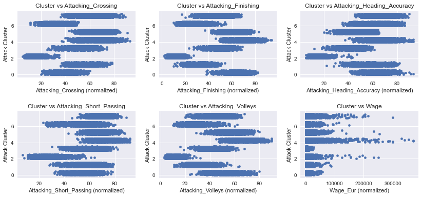

```python
from matplotlib import pyplot as plt
plt.style.use("seaborn")

%matplotlib inline
X1 = X_attack_cls_df[['Attack_cls','Attacking_Crossing','Attacking_Finishing',
                      'Attacking_Heading_Accuracy','Attacking_Short_Passing',
                     'Attacking_Volleys','Wage_Eur']].values  # create new matrix with pd.ndarray

_ = plt.subplots(2,3, figsize=(14,6))
_ = plt.subplots_adjust(hspace=.5)
_ = plt.subplot(231)
_ = plt.scatter(X1[:, 1], X1[:, 0]+np.random.random(X1[:, 1].shape)/2, s=20)
_ = plt.xlabel('Attacking_Crossing (normalized)'), plt.ylabel('Attack Cluster')
_ = plt.title('Cluster vs Attacking_Crossing');

_ = plt.subplot(232)
_ = plt.scatter(X1[:, 2], X1[:, 0]+np.random.random(X1[:, 1].shape)/2, s=20);
_ = plt.xlabel('Attacking_Finishing (normalized)'), plt.ylabel('Attack Cluster')
_ = plt.title('Cluster vs Attacking_Finishing');

_ = plt.subplot(233)
_ = plt.scatter(X1[:, 3], X1[:, 0]+np.random.random(X1[:, 1].shape)/2, s=20);
_ = plt.xlabel('Attacking_Heading_Accuracy (normalized)'), plt.ylabel('Attack Cluster')
_ = plt.title('Cluster vs Attacking_Heading_Accuracy');

_ = plt.subplot(234)
_ = plt.scatter(X1[:, 4], X1[:, 0]+np.random.random(X1[:, 1].shape)/2, s=20);
_ = plt.xlabel('Attacking_Short_Passing (normalized)'), plt.ylabel('Attack Cluster')
_ = plt.title('Cluster vs Attacking_Short_Passing');

_ = plt.subplot(235)
_ = plt.scatter(X1[:, 5], X1[:, 0]+np.random.random(X1[:, 1].shape)/2, s=20);
_ = plt.xlabel('Attacking_Volleys (normalized)'), plt.ylabel('Attack Cluster')
_ = plt.title('Cluster vs Attacking_Volleys');

_ = plt.subplot(236)
_ = plt.scatter(X1[:, 6], X1[:, 0]+np.random.random(X1[:, 1].shape)/2, s=20)
_ = plt.xlabel('Wage_Eur (normalized)')
_ = plt.ylabel('Attack Cluster')
_ = plt.title('Cluster vs Wage')
plt.show()
```

⏫ Table of Contents

# 4. Modeling and Evaluation 1: Train and adjust parameters

In the last two labs, we used supervised learning techniques to build machine learning models. Now we will explore cluster analyis and PCA, a category of unsupervised learning that allows us to discover hidden data structures. The goal of clustering analysis is to find the natural grouping in data. We will do the clustering on scaled dataset from now on.

In the first step, we will consider regression analysis and compare it with clustering analysis.

#### **Regression Task**

```python
#create a list of columns that we will include in our final dataset for our task 2
l=df_mental_attr.append(df_attacking_attr).append(df_skill_attr).append(df_movement_attr).append(df_power_attr).append(df_defending_attr)
l=l.append(pd.Series(['age','international_reputation','value_eur','overall','height_cm','weight_kg']))

#create a list of columns without 'attacking' group which is used for clustering
l_r =df_mental_attr.append(df_skill_attr).append(df_movement_attr).append(df_power_attr).append(df_defending_attr)
l_r =l_r.append(pd.Series(['age','international_reputation','value_eur','overall','height_cm','weight_kg']))

# df_players_reg: data frame with 35 features
df_players_reg = df_players[l].copy()
# df_reg_cls: data frame with 30 features, excluding 'attacking' features
df_reg_cls = df_players[l_r].copy()
#df_attack: data frame with 5 'attacking' features
df_attack = df_players[df_attacking_attr]

# df_players_reg_cls = df_players[l_r].copy()
# df_players_reg_cls['X_attack_cls'] = X_attack_cls

# df_players_reg: data frame with 49 features (35+14) including the one-hot encoded position features
df_players_reg = pd.concat([df_players_reg, p], axis=1)
# df_players_reg_cls: data frame with 44 features (30+14) including the one-hot encoded position features
df_reg_cls = pd.concat([df_reg_cls, p], axis=1)
print('DataFrame \'df_players_reg\' shape: ', df_players_reg.shape)
print('DataFrame \'df_reg_cls\' shape: ', df_reg_cls.shape)
print('DataFrame \'df_attack\' shape: ', df_attack.shape)
# df_players_reg_cls = pd.concat([df_players_reg_cls, p], axis=1)

# transform to pd.Series
players_reg_X = df_players_reg.values  # Series with 49 features
players_reg_cls_X = df_reg_cls.values # Series with 44 features
players_reg_cls_attack = df_attack.values # Series with 5 'attacking' features
players_reg_y = df_players['wage_eur'].values # Series with 1 label

# scaling data
scl_obj = StandardScaler()
_ = scl_obj.fit(players_reg_X)
X_players_reg_scaled = scl_obj.transform(players_reg_X) # Series with 49 scaled features

scl_cls_obj = StandardScaler()
_ = scl_cls_obj.fit(players_reg_cls_X)
X_players_reg_cls_scaled = scl_cls_obj.transform(players_reg_cls_X) # Series with 44 scaled features
X_players_reg_cls_scaled_52 = np.column_stack((players_reg_cls_X,pd.get_dummies(X_attack_cls)))
# Series with 52 scaled features (44+8 one_hot features KMeans)

scl_attack_obj = StandardScaler()
_ = scl_attack_obj.fit(players_reg_cls_attack)
X_players_attack_scaled = scl_attack_obj.transform(players_reg_cls_attack) # Series with 5 scaled features

print('\nScaled Series \'X_players_reg_scaled\' shape: ', X_players_reg_scaled.shape)
print('Scaled Series \'X_players_reg_cls_scaled\' shape: ', X_players_reg_cls_scaled.shape)
print('Scaled Series \'X_players_attack_scaled\' shape: ', X_players_attack_scaled.shape)
print('Scaled Series \'X_players_reg_cls_scaled_52\' shape: ', X_players_reg_cls_scaled_52.shape)
```

```
DataFrame 'df_players_reg' shape:  (18275, 49)
DataFrame 'df_reg_cls' shape:  (18275, 44)
DataFrame 'df_attack' shape:  (18275, 5)

Scaled Series 'X_players_reg_scaled' shape:  (18275, 49)
Scaled Series 'X_players_reg_cls_scaled' shape:  (18275, 44)
Scaled Series 'X_players_attack_scaled' shape:  (18275, 5)
Scaled Series 'X_players_reg_cls_scaled_52' shape:  (18275, 52)
```

### Regression Task dataset summary

```python
df_players_reg.shape
df_players_reg.describe()
df_players_reg.info(verbose=True, null_counts=True)
```

```
(18275, 49)
```

|  | mentality_aggression | mentality_interceptions | mentality_positioning | mentality_vision | mentality_penalties | mentality_composure | attacking_crossing | attacking_finishing | attacking_heading_accuracy | attacking_short_passing | ... | 4 | 5 | 6 | 7 | 8 | 9 | 10 | 11 | 12 | 13 |
| --- | --- | --- | --- | --- | --- | --- | --- | --- | --- | --- | --- | --- | --- | --- | --- | --- | --- | --- | --- | --- | --- |
| count | 18275.000000 | 18275.000000 | 18275.000000 | 18275.000000 | 18275.000000 | 18275.000000 | 18275.000000 | 18275.000000 | 18275.000000 | 18275.000000 | ... | 18275.000000 | 18275.000000 | 18275.000000 | 18275.000000 | 18275.000000 | 18275.000000 | 18275.000000 | 18275.000000 | 18275.000000 | 18275.000000 |
| mean | 55.742271 | 46.381833 | 50.065280 | 53.604049 | 48.377729 | 58.522955 | 49.712722 | 45.582763 | 52.218003 | 58.743201 | ... | 0.111409 | 0.071300 | 0.057401 | 0.020629 | 0.004925 | 0.071902 | 0.057456 | 0.020137 | 0.003776 | 0.141231 |
| std | 17.319396 | 20.777028 | 19.588211 | 13.949535 | 15.703083 | 11.873086 | 18.321503 | 19.587474 | 17.427119 | 14.675994 | ... | 0.314647 | 0.257332 | 0.232613 | 0.142144 | 0.070006 | 0.258332 | 0.232717 | 0.140472 | 0.061332 | 0.348269 |
| min | 9.000000 | 3.000000 | 2.000000 | 9.000000 | 7.000000 | 12.000000 | 5.000000 | 2.000000 | 5.000000 | 7.000000 | ... | 0.000000 | 0.000000 | 0.000000 | 0.000000 | 0.000000 | 0.000000 | 0.000000 | 0.000000 | 0.000000 | 0.000000 |
| 25% | 44.000000 | 25.000000 | 39.000000 | 44.000000 | 39.000000 | 51.000000 | 38.000000 | 30.000000 | 44.000000 | 54.000000 | ... | 0.000000 | 0.000000 | 0.000000 | 0.000000 | 0.000000 | 0.000000 | 0.000000 | 0.000000 | 0.000000 | 0.000000 |
| 50% | 58.000000 | 52.000000 | 55.000000 | 55.000000 | 49.000000 | 60.000000 | 54.000000 | 49.000000 | 56.000000 | 62.000000 | ... | 0.000000 | 0.000000 | 0.000000 | 0.000000 | 0.000000 | 0.000000 | 0.000000 | 0.000000 | 0.000000 | 0.000000 |
| 75% | 69.000000 | 64.000000 | 64.000000 | 64.000000 | 60.000000 | 67.000000 | 64.000000 | 62.000000 | 64.000000 | 68.000000 | ... | 0.000000 | 0.000000 | 0.000000 | 0.000000 | 0.000000 | 0.000000 | 0.000000 | 0.000000 | 0.000000 | 0.000000 |
| max | 95.000000 | 92.000000 | 93.000000 | 94.000000 | 92.000000 | 95.000000 | 93.000000 | 94.000000 | 93.000000 | 92.000000 | ... | 1.000000 | 1.000000 | 1.000000 | 1.000000 | 1.000000 | 1.000000 | 1.000000 | 1.000000 | 1.000000 | 1.000000 |

8 rows × 49 columns

```
<class 'pandas.core.frame.DataFrame'>
RangeIndex: 18275 entries, 0 to 18274
Data columns (total 49 columns):
 #   Column                      Non-Null Count  Dtype
---  ------                      --------------  -----
 0   mentality_aggression        18275 non-null  int64
 1   mentality_interceptions     18275 non-null  int64
 2   mentality_positioning       18275 non-null  int64
 3   mentality_vision            18275 non-null  int64
 4   mentality_penalties         18275 non-null  int64
 5   mentality_composure         18275 non-null  int64
 6   attacking_crossing          18275 non-null  int64
 7   attacking_finishing         18275 non-null  int64
 8   attacking_heading_accuracy  18275 non-null  int64
 9   attacking_short_passing     18275 non-null  int64
```

[output cut: 41 more lines]

```python
df_players['wage_eur'].value_counts(bins=15, normalize=True)*100
```

```
(630.999, 25600.0]      91.255814
(25600.0, 50200.0]       5.619699
(50200.0, 74800.0]       1.504788
(74800.0, 99400.0]       0.689466
(99400.0, 124000.0]      0.251710
(124000.0, 148600.0]     0.218878
(148600.0, 173200.0]     0.136799
(173200.0, 197800.0]     0.103967
(197800.0, 222400.0]     0.082079
(222400.0, 247000.0]     0.049248
(247000.0, 271600.0]     0.027360
(345400.0, 370000.0]     0.016416
(296200.0, 320800.0]     0.016416
(271600.0, 296200.0]     0.016416
(320800.0, 345400.0]     0.010944
Name: wage_eur, dtype: float64
```

We now prepare test train data set.

```python
# Lets create the test/train 80/20 split indexes using stratifiedshuffle split due to
# some imbalance in the classes as seen above
from sklearn.model_selection import train_test_split

bins = np.linspace(0, 565000.0, 15)
bins
# Save your Y values in a new ndarray,
# broken down by the bins created above.

y_binned = np.digitize(players_reg_y, bins)

# Pass y_binned to the stratify argument,
# and sklearn will handle the rest

X_reg_train, X_reg_test, y_reg_train, y_reg_test = train_test_split(X_players_reg_scaled, players_reg_y,
                                                    test_size=0.2, stratify=y_binned, random_state= 45)

X_reg_cls_train, X_reg_cls_test, y_reg_cls_train, y_reg_cls_test = train_test_split(X_players_reg_cls_scaled_52, players_reg_y,
                                                    test_size=0.2, stratify=y_binned, random_state= 45)
```

```
array([     0.        ,  40357.14285714,  80714.28571429, 121071.42857143,
       161428.57142857, 201785.71428571, 242142.85714286, 282500.        ,
       322857.14285714, 363214.28571429, 403571.42857143, 443928.57142857,
       484285.71428571, 524642.85714286, 565000.        ])
```

```python
#We will store each model performace numCVs=10stats in this dataframe
model_clf_stats = pd.DataFrame()
model_reg_stats = pd.DataFrame()
model_reg_lda_stats = pd.DataFrame()
model_reg_yhat = pd.DataFrame()
numCVs=10
```

#### Custom Scorers for Evaluating Regression Models

**All regression models created in this notebook are validated using the following metrics:**

- Mean Absolute Error (MAE)

Common methods used for scoring

```python
#Use mean absolute error (MAE) to score the regression models created
#(the scale of MAE is identical to the response variable)
from sklearn.metrics import mean_absolute_error, make_scorer, mean_squared_error, r2_score

#Function for Root mean squared error
#https://stackoverflow.com/questions/17197492/root-mean-square-error-in-python
def rmse(y_actual, y_predicted):
    return np.sqrt(mean_squared_error(y_actual, y_predicted))

#Function for Mean Absolute Percentage Error (MAPE) - Untested
#Adapted from - https://stackoverflow.com/questions/42250958/how-to-optimize-mape-code-in-python
def mape(y_actual, y_predicted):
    mask = y_actual != 0
    return (np.fabs(y_actual - y_predicted)/y_actual)[mask].mean() * 100

#Create scorers for rmse and mape functions
mae_scorer = make_scorer(score_func=mean_absolute_error, greater_is_better=False)
rmse_scorer = make_scorer(score_func=rmse, greater_is_better=False)
mape_scorer = make_scorer(score_func=mape, greater_is_better=False)
r2_scorer = make_scorer(score_func=r2_score, greater_is_better=True)

#Make scorer array to pass into cross_validate() function for producing mutiple scores for each cv fold.
errorScoring = {'MAE':  mae_scorer,
                'RMSE': rmse_scorer,
                'MAPE': mape_scorer,
                'R2': r2_scorer,
                }
```

```python
from sklearn.model_selection import cross_validate
import seaborn as sns
# colors = ["windows blue", "amber", "greyish", "faded green", "dusty purple"]
# pal = sns.xkcd_palette(colors)
import pprint

def EvaluateRegressionEstimator(regEstimator, X, y, cv):

    scores = cross_validate(regEstimator, X, y, scoring=errorScoring, cv=cv, return_train_score=True)
    #print('scores = \n')
    #pp = pprint.PrettyPrinter(indent=1)
    #pp.pprint(scores)

    #cross val score sign-flips the outputs of MAE
    # https://github.com/scikit-learn/scikit-learn/issues/2439
    scores['test_MAE'] = scores['test_MAE'] * -1
    scores['test_MAPE'] = scores['test_MAPE'] * -1
    scores['test_RMSE'] = scores['test_RMSE'] * -1

    #print mean MAE for all folds
    maeAvg = scores['test_MAE'].mean()
    print_str = "The average MAE for all cv folds is: \t\t\t {maeAvg:.5}"
    print(print_str.format(maeAvg=maeAvg))

    #print mean test_MAPE for all folds
    scores['test_MAPE'] = scores['test_MAPE']
    mape_avg = scores['test_MAPE'].mean()
    print_str = "The average MAE percentage (MAPE) for all cv folds is: \t {mape_avg:.5}"
    print(print_str.format(mape_avg=mape_avg))

    #print mean MAE for all folds
    RMSEavg = scores['test_RMSE'].mean()
    print_str = "The average RMSE for all cv folds is: \t\t\t {RMSEavg:.5}"
    print(print_str.format(RMSEavg=RMSEavg))

    #print mean R2 for all folds
    R2avg = scores['test_R2'].mean()
    print_str = "The average R2 for all cv folds is: \t\t\t {R2avg:.5}"
    print(print_str.format(R2avg=R2avg))
    print('*********************************************************')

    print('Cross Validation Fold Mean Error Scores')
    scoresResults = pd.DataFrame()
    scoresResults['MAE'] = scores['test_MAE']
    scoresResults['MAPE'] = scores['test_MAPE']
    scoresResults['RMSE'] = scores['test_RMSE']
    scoresResults['R2'] = scores['test_R2']
    print(scoresResults)
    return scoresResults

def plot_kde_y_yhat(y, y_):
    plot_df = pd.DataFrame()
    plot_df['y'] = y
    plot_df['yhat'] = y_

    # Change negative yhat to 0 as wage can't be negative value
    plot_df[plot_df['yhat']<0] = 0
    ax1 = sns.distplot(plot_df['y'], kde=True, color='#4472C4', hist=False, label='Actual wages')
    sns.distplot(plot_df['yhat'], kde=True, color='#FF9900', hist=False, label='Predicted wages', ax=ax1)
    ax1.set(xlim=(-10000,150000))
    ax1.set_title("Actual wages vs. Predicted wages")
    plt.xlabel('Wages (€)')
    plt.ylabel('Gaussian Kernel Density Estimate')
```

evaluate_reg_model_performance methods uses a grid searchCV scikitlearn api to evaluate a set of models that are passed to it. The best performing model is identified with the graphs show comparative statistics. The evaluation is done as follows:  
model_name: string representing the model name can be anything  
params: List of model tuning paramters clf: the estimator classification to evaluate  
X_train, y_train: The scaled train dataset, the grid search will use this data set and run internal CV to evaluate the model passed  
X_test, y_test: this test data set for best model estimated.  
nCV: Number of cross validation to run

Returns : modal_stats: a summary of best model

```python
import warnings
warnings.filterwarnings('ignore')

from sklearn.metrics import make_scorer
from sklearn.metrics import mean_squared_error
from sklearn.metrics import mean_absolute_error
from sklearn.metrics import r2_score
import pprint
from yellowbrick.regressor import ResidualsPlot
from yellowbrick.regressor import PredictionError
from yellowbrick.regressor import CooksDistance
plt.style.use('seaborn')
%matplotlib inline

def evaluate_reg_model_performance(model_name,params,clf,score,X_train,y_train,X_test,y_test,nCV=10,n_jobs=1):
    # We prepare the grid search object
    # and custom scorer
    mape_scorer = make_scorer(score_func=mape, greater_is_better=False)
    scoring = {'RMSE': 'neg_root_mean_squared_error',
               'MAE': 'neg_mean_absolute_error',
               'MAPE': mape_scorer,
               'R2': 'r2'}

    grid = gridcv(clf, params, cv=nCV, scoring=scoring, n_jobs=n_jobs, refit=score, return_train_score=True)
    grid.fit(X_train, y_train)
    model_stat = pd.DataFrame()
    model_stat['model_name'] = [str(model_name)]
    print("Best parameters set found:")
    print(grid.best_params_)
    res = grid.cv_results_
    #pp = pprint.PrettyPrinter(indent=1)
    #pp.pprint(res)

    grid_scr = pd.DataFrame()
    grid_scr['params'] = res['params']
    grid_scr['RMSE'] = -res['mean_test_RMSE']
    grid_scr['MAPE'] = -res['mean_test_MAPE']
    grid_scr['MAE'] = -res['mean_test_MAE']
    grid_scr['R2'] = res['mean_fit_time']

    grid_scr = pd.DataFrame(grid_scr)
    print('\nMean score summary of each gridsearch estimator executed')
    #display(Markdown(grid_scr.to_markdown()))

    x = np.arange(len(grid_scr['params'])).astype(int)

    plt.subplots(2, 2, figsize=(12, 6))

    plt.subplot(221)
    plt.bar(x, grid_scr['RMSE'])
    plt.ylabel('RMSE')
    #plt.xlabel('Parameter')
    plt.title('RMSE mean scores (nCV=%i)'%nCV)
    plt.grid(color='grey', linestyle='--', linewidth=0.3)

    plt.subplot(222)
    plt.bar(x, grid_scr['MAPE'])
    plt.ylabel('MAPE')
    #plt.xlabel('Parameter')
    plt.title('MAPE mean scores (nCV=%i)'%nCV)
    plt.grid(color='grey', linestyle='--', linewidth=0.3)

    plt.subplot(223)
    plt.bar(x, grid_scr['MAE'])
    plt.ylabel('MAE')
    plt.xlabel('Parameter')
    plt.title('MAE mean scores (nCV=%i)'%nCV)
    plt.grid(color='grey', linestyle='--', linewidth=0.3)

    plt.subplot(224)
    plt.bar(x, grid_scr['R2'])
    plt.ylabel('R2')
    plt.xlabel('Parameter')
    plt.title('R2 mean scores (nCV=%i)'%nCV)
    plt.grid(color='grey', linestyle='--', linewidth=0.3)

    plt.subplots_adjust(left=0.125, right=0.8, wspace=0.3, hspace=0.4)
    plt.show()

    print(nCV, 'fold cross validation average scores of the best Estimator found by GridSearchCV\n')
    e = EvaluateRegressionEstimator(grid.best_estimator_, X_train, y_train, nCV)
    model_stat['model_name']
    model_stat['RMSE'] = grid_scr['RMSE']
    model_stat['MAPE'] = grid_scr['MAPE']
    model_stat['MAE'] = grid_scr['MAE']
    #model_stat['R2'] = grid_scr['R2']
    model_stat['time_refit'] = [grid.refit_time_]
    #display(Markdown(e.to_markdown()))
    #prediction

    if model_name in ['Linear Reg', 'Lasso Reg', 'Ridge Reg', 'Linear Reg_LDA', 'Lasso Reg_LDA', 'Ridge Reg_LDA']:
        plt.subplots(1, 2, figsize=(12, 4))
        plt.subplot(121)
        grid.fit(X_train, y_train)
        yhat = grid.predict(X_test)
        plot_kde_y_yhat(y_test, yhat)

        plt.subplot(122)
        visualizer = ResidualsPlot(clf)
        visualizer.fit(X_train, y_train)
        visualizer.score(X_test, y_test)
        visualizer.show()
        plt.show()

        plt.subplots(1, 2, figsize=(13,4))
        plt.subplot(121)
        visualizer = PredictionError(clf)
        visualizer.fit(X_train, y_train)
        visualizer.score(X_test, y_test)
        visualizer.finalize()

        plt.subplot(122)
        visualizer = CooksDistance()
        visualizer.fit(X_test, y_test)
        visualizer.finalize()
        plt.show()
    else:
        grid.fit(X_train, y_train)
        yhat = grid.predict(X_test)
        plot_kde_y_yhat(y_test, yhat)

    yhat_df = pd.DataFrame(yhat)
    yhat_df = yhat_df.rename({0: model_name}, axis='columns')

    return (model_stat, yhat_df)
```

⏫ Table of Contents

# 5. Modeling and Evaluation 2: Evaluate and Compare

In this subsection we will evaluate the following clustering algorithms,

- KMeans
- AgglomerativeClustering Model
- DBScan
- Gaussian Mixture
- Spectral Clustring

```python
##Scale the transformed data
scl_obj = StandardScaler()
scl_obj.fit(players_reg_X)
X_players_reg_scaled = scl_obj.transform(players_reg_X)
```

```
StandardScaler()
```

### KMeans Model

In this subsection, we will use KMeans techniques to build models. This technique is used widely in academia as well as in industry. KMeans techniques is easy to implement. In addition, it is also computationally very efficient. However, the clustering result can be bad or slow convergence if the initial centroids are chosen poorly. A smarter way of placing the initial cluster centroids in our lab is to use KMeans ++ which leads to better and more consistent results than the classical KMeans.

```python
import warnings
warnings.filterwarnings('ignore')
from sklearn.cluster import KMeans
from sklearn.cluster import AgglomerativeClustering
from sklearn.cluster import DBSCAN
from sklearn.model_selection import cross_validate
from sklearn.linear_model import LinearRegression
from sklearn import metrics
linreg = LinearRegression()

# DataFrame 'df_players_reg' shape:  (18275, 49)
# DataFrame 'df_reg_cls' shape:  (18275, 44)
# DataFrame 'df_attack' shape:  (18275, 5)

# Scaled Series 'X_players_reg_scaled' shape:  (18275, 49)
# Scaled Series 'X_players_reg_cls_scaled' shape:  (18275, 44)
# Scaled Series 'X_players_attack_scaled' shape:  (18275, 5)
# players_reg_y = df_players['wage_eur'].values # (18275, 1)

X_attack_cls_df = None
inertia_dict = {}
seuclid = []
scosine = []

for n_cls in range(2,9):
    cls1 = KMeans(n_clusters=n_cls, init='k-means++', random_state=52)
    results = cls1.fit(X_players_attack_scaled)
    newfeature_attack = cls1.labels_
    inertia_dict[n_cls] = results.inertia_
    seuclid.append(metrics.silhouette_score(X_players_attack_scaled, newfeature_attack, metric='euclidean'))
    scosine.append(metrics.silhouette_score(X_players_attack_scaled, newfeature_attack, metric='cosine'))

    y = df_players['wage_eur']
    X = X_players_reg_cls_scaled
    X = np.column_stack((X, pd.get_dummies(newfeature_attack)))

    # write into cluster data frame
    df1 = pd.DataFrame(newfeature_attack)
    X_attack_cls_df = [X_attack_cls_df,df1]
    X_attack_cls_df = pd.concat(X_attack_cls_df, axis=1, ignore_index=True)

    # calculate scores and print
    scores = cross_validate(linreg, X, y, scoring=errorScoring, cv=10, return_train_score=True)
    scores['test_MAE'] = scores['test_MAE'] * -1
    maeAvg = scores['test_MAE'].mean()
    print("Average MAE (KMeans " + str(n_cls) + " clusters) = ", maeAvg)

inertia_df = pd.DataFrame(list(inertia_dict.items()), columns=['K', 'SSE'])
```

```
Average MAE (KMeans 2 clusters) =  4584.838397101854
Average MAE (KMeans 3 clusters) =  4600.369158779666
Average MAE (KMeans 4 clusters) =  4591.457048368578
Average MAE (KMeans 5 clusters) =  4596.370444522216
Average MAE (KMeans 6 clusters) =  4605.460100872639
Average MAE (KMeans 7 clusters) =  4612.2757290621275
Average MAE (KMeans 8 clusters) =  364864586228.61194
```

```python
df_clustersummary = pd.DataFrame()
df_cluster = pd.DataFrame()
df_cluster['model_name'] = ['KMeans']
df_cluster['BestCluster'] = ['3']
df_cluster['Param'] = ['3 clusters']
df_cluster['MAE'] = ['4600.36']
df_clustersummary = df_clustersummary.append(df_cluster)
```

We now use the elbow method to find the optimal number of clusters. One of the main challenges in unsupervised learning is that we do not know the definitive answer. Based on the within-cluster SSE, we can use a graphical tool, **elbow method**, to estimate the optimal number of cluster $k$.

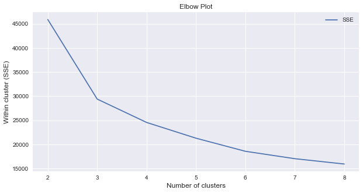

```python
plt.rcParams["figure.figsize"] = (10,5)
aw1 = inertia_df.plot(x='K', y='SSE')
plt.xlabel('Number of clusters', size=12)
plt.ylabel('Within cluster (SSE)', size=12)
plt.title('Elbow Plot');
```

The inertia drops quickly as we increase $k$ up to 3 and then decreases more slowly when $k$ increasing. If we do not know better, 3 is the good choice.

For KMeans two clusters have the lowest MAE score but the elbow plot indicates either three or four to be optimal.

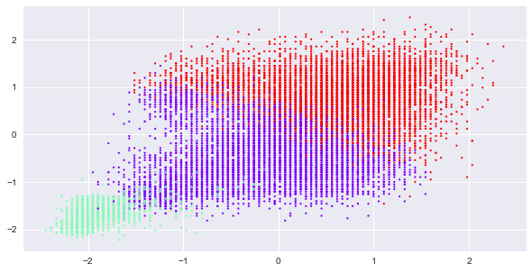

```python
dbs = KMeans(n_clusters=3, init='k-means++', random_state=52)
dbsfit =  dbs.fit(X_players_attack_scaled)
labels = dbsfit.labels_

plt.figure(figsize=(10,5))
plt.scatter(X_players_attack_scaled[:, 0], X_players_attack_scaled[:, 1], c=labels,cmap=plt.cm.rainbow, s=5, linewidths=0)
plt.show()
```

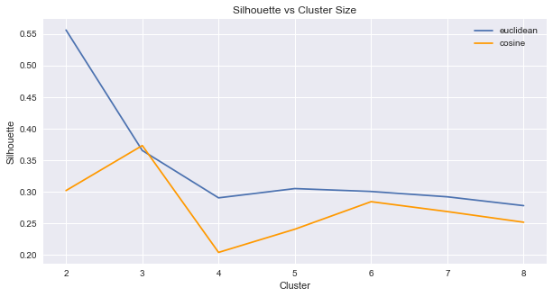

```python
_ = plt.figure(figsize=(10,5))
_ = plt.plot(range(2,9),seuclid,label='euclidean')
_ = plt.plot(range(2,9),scosine,label='cosine',color='#FF9900')
_ = plt.ylabel("Silhouette")
_ = plt.xlabel("Cluster")
_ = plt.title("Silhouette vs Cluster Size")
_ = plt.legend()
_ = plt.show()
```

### Clustering Evaluation

Next we use Silhouette Coefficient to do the clustering evaluation.

Silhouette refers to a method of interpretation and validation of consistency within clusters of data. The technique provides a succinct graphical representation of how well each object has been classified.

The silhouette value is a measure of how similar an object is to its own cluster (cohesion) compared to other clusters (separation). The silhouette ranges from −1 to +1, where a high value indicates that the object is well matched to its own cluster and poorly matched to neighboring clusters. If most objects have a high value, then the clustering configuration is appropriate. If many points have a low or negative value, then the clustering configuration may have too many or too few clusters.

The silhouette can be calculated with any distance metric, such as the Euclidean distance or the Manhattan distance.

https://en.wikipedia.org/wiki/Silhouette

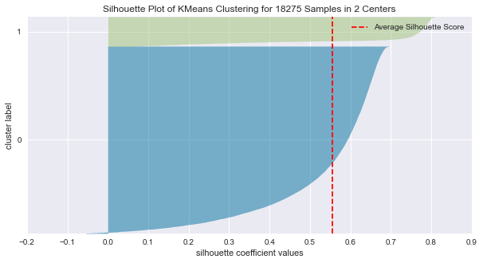

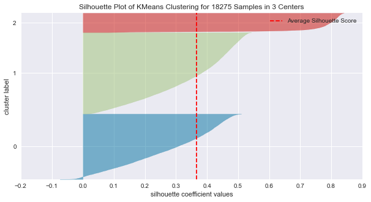

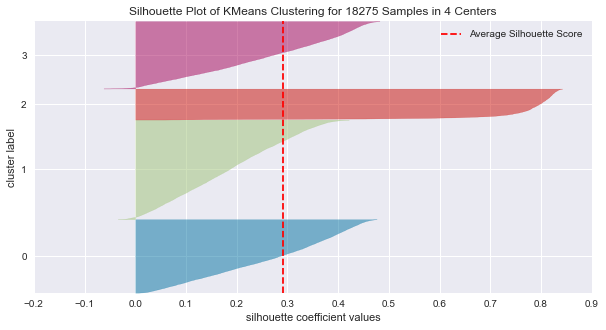

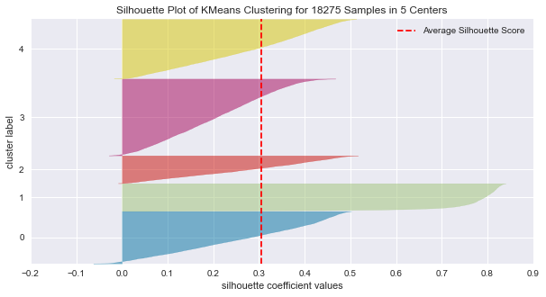

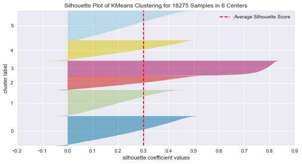

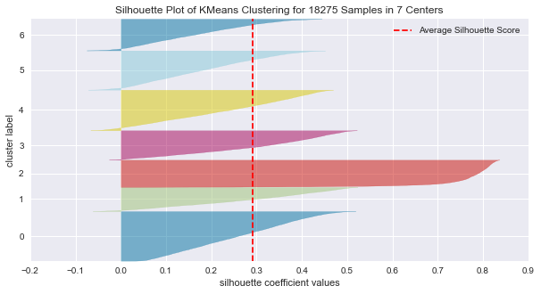

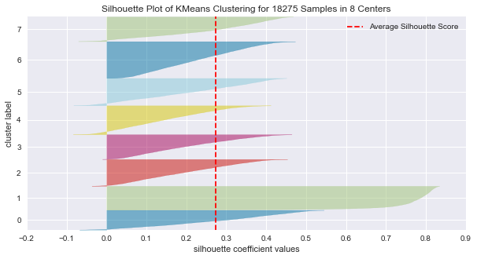

```python
from sklearn.cluster import KMeans
from yellowbrick.cluster import SilhouetteVisualizer
from yellowbrick.datasets import load_nfl

# Load a clustering dataset
X = X_players_attack_scaled

range_n_clusters = range(2, 9)
for k in range_n_clusters:
    # Instantiate the clustering model and visualizer
    model = KMeans(k, random_state=42)
    visualizer = SilhouetteVisualizer(model, colors='yellowbrick')
    _ = visualizer.fit(X)        # Fit the data to the visualizer
    _ = visualizer.show()        # Finalize and render the figure
```

```python
import matplotlib.cm as cm
from sklearn.metrics import silhouette_score, silhouette_samples
cmap = cm.get_cmap("Spectral")
X = X_players_attack_scaled
silhouette_dict = {}
range_n_clusters = range(2, 9)
for n_clusters in range_n_clusters:
    # Create a subplot with 1 row and 2 columns
    #fig, ax1 = plt.subplots(1)
    #fig.set_size_inches(5, 5)
    # This subplot is the silhouette plot
    # The silhouette coefficient can range from -1, 1 but in this example all
    # lie within [-0.1, 1]
    #ax1.set_xlim([-0.1, 1])
    # The (n_clusters+1)*10 is for inserting blank space between silhouette
    # plots of individual clusters, to demarcate them clearly.
    #ax1.set_ylim([0, len(X) + (n_clusters + 1) * 10])
    # Initialize the clusterer with n_clusters value and a random generator
    # seed of 10 for reproducibility.
    clusterer = KMeans(n_clusters=n_clusters, random_state=10)
    cluster_labels = clusterer.fit_predict(X)
# The silhouette_score gives the average value for all the samples.
    # This gives a perspective into the density and separation of the formed
    # clusters
    silhouette_avg = silhouette_score(X, cluster_labels)
    print("For n_clusters =", n_clusters,
          "The average silhouette_score is :", silhouette_avg)
    silhouette_dict[n_clusters] = silhouette_avg
```

```
For n_clusters = 2 The average silhouette_score is : 0.5561575456663519
For n_clusters = 3 The average silhouette_score is : 0.36551620775945287
For n_clusters = 4 The average silhouette_score is : 0.29102662040788757
For n_clusters = 5 The average silhouette_score is : 0.30506122073461434
For n_clusters = 6 The average silhouette_score is : 0.3007749986749822
For n_clusters = 7 The average silhouette_score is : 0.2907215006643499
For n_clusters = 8 The average silhouette_score is : 0.2691259719855152
```

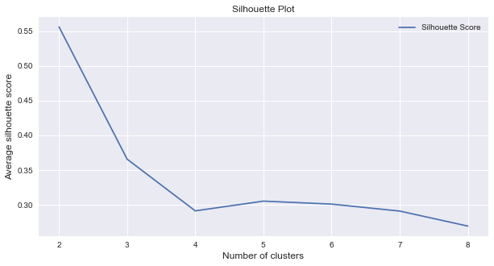

```python
silhouette_df = pd.DataFrame(list(silhouette_dict.items()), columns=['K', 'Silhouette Score'])
plt.rcParams["figure.figsize"] = (10,5)
silhouette_df.plot(x='K', y='Silhouette Score')
plt.xlabel('Number of clusters', size=12)
plt.ylabel('Average silhouette score', size=12)
plt.xticks(size=10)
plt.yticks(size=10)
plt.title('Silhouette Plot');
```

### AgglomerativeClustering Model

Agglomerative Clustering is one of the most common hierarchical clustering techniques. The clustering technique assumes that each data point is similar enough to the other data points that the data at the starting can be assumed to be clustered in 1 cluster.

```python
from sklearn.cluster import AgglomerativeClustering
from sklearn.model_selection import cross_validate
from sklearn.linear_model import LinearRegression
linreg = LinearRegression()

for link in ['ward', 'complete', 'average']:
    for n_cls in range(2,5):
        cls2 = AgglomerativeClustering(n_clusters=n_cls, linkage=link)
        _ = cls2.fit(X_players_attack_scaled)
        newfeature_attack = cls2.labels_

        y = df_players['wage_eur']
        X = X_players_reg_cls_scaled
        X = np.column_stack((X, pd.get_dummies(newfeature_attack)))

        # write into cluster data frame
        df1 = pd.DataFrame(X_attack_cls)
        X_attack_cls_df = [X_attack_cls_df,df1]
        X_attack_cls_df = pd.concat(X_attack_cls_df, axis=1, ignore_index=True)

        # calculate scores and print
        scores = cross_validate(linreg, X, y, scoring=errorScoring, cv=10, return_train_score=True)
        scores['test_MAE'] = scores['test_MAE'] * -1
        maeAvg = scores['test_MAE'].mean()
        print("Average MAE (AgglomerativeClustering, link=" + link + ", " + str(n_cls)+" clusters) = ", maeAvg)

df_cluster = pd.DataFrame()
df_cluster['model_name'] = ['AgglomerativeClustering']
df_cluster['BestCluster'] = ['3']
df_cluster['Param'] = ['link=complete, 3 clusters']
df_cluster['MAE'] = ['4586.09']
df_clustersummary = df_clustersummary.append(df_cluster)
```

```
Average MAE (AgglomerativeClustering, link=ward, 2 clusters) =  4589.22774135979
Average MAE (AgglomerativeClustering, link=ward, 3 clusters) =  4592.452165666871
Average MAE (AgglomerativeClustering, link=ward, 4 clusters) =  4594.730029888286
Average MAE (AgglomerativeClustering, link=complete, 2 clusters) =  4588.838758343377
Average MAE (AgglomerativeClustering, link=complete, 3 clusters) =  4586.091143229575
Average MAE (AgglomerativeClustering, link=complete, 4 clusters) =  4593.880097011607
Average MAE (AgglomerativeClustering, link=average, 2 clusters) =  529342790567.43585
Average MAE (AgglomerativeClustering, link=average, 3 clusters) =  6586733387407.998
Average MAE (AgglomerativeClustering, link=average, 4 clusters) =  33359854109646.04
```

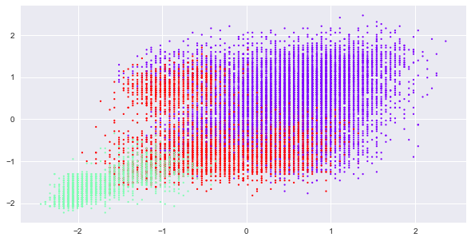

```python
dbs = AgglomerativeClustering(n_clusters=3, linkage='complete')
dbsfit =  dbs.fit(X_players_attack_scaled)
labels = dbsfit.labels_

plt.figure(figsize=(10,5))
plt.scatter(X_players_attack_scaled[:, 0], X_players_attack_scaled[:, 1], c=labels,cmap=plt.cm.rainbow, s=5, linewidths=0)
plt.show()
```

In AgglomerativeClustering ward and complete give a better score than average.

### DBSCAN Model

This DBSCAN method (Density-based spatial clustering of applications with noise) does not make any assumption about spherical clusters like KMeans, nor does it partition the dataset into hierarchies that require a manual cut-off point.

```python
for eps in [0.1, 0.125, 0.15]:
    for mpts in range(3,9):
        cls3 = DBSCAN(eps=eps, min_samples=mpts)
        _ = cls3.fit(X_players_attack_scaled)
        newfeature_attack = cls3.labels_
        y = df_players['wage_eur']
        X = X_players_reg_cls_scaled
        X = np.column_stack((X, pd.get_dummies(newfeature_attack)))

        # write into cluster data frame
        df1 = pd.DataFrame(X_attack_cls)
        X_attack_cls_df = [X_attack_cls_df,df1]
        X_attack_cls_df = pd.concat(X_attack_cls_df, axis=1, ignore_index=True)

        # calculate scores and print
        scores = cross_validate(linreg, X, y, scoring=errorScoring, cv=10, return_train_score=True)
        scores['test_MAE'] = scores['test_MAE'] * -1
        maeAvg = scores['test_MAE'].mean()
        print("Average MAE (DBSCAN, eps=" + str(eps) + ", min_points=" + str(mpts) +") = ", maeAvg)

df_cluster = pd.DataFrame()
df_cluster['model_name'] = ['DBScan']
df_cluster['BestCluster'] = ['3']
df_cluster['Param'] = ['minpoint=6, eps=.125']
df_cluster['MAE'] = ['4568.05']
df_clustersummary = df_clustersummary.append(df_cluster)
```

```
Average MAE (DBSCAN, eps=0.1, min_points=3) =  4604.587360022011
Average MAE (DBSCAN, eps=0.1, min_points=4) =  4602.61416390898
Average MAE (DBSCAN, eps=0.1, min_points=5) =  4593.365600737644
Average MAE (DBSCAN, eps=0.1, min_points=6) =  4590.845086245414
Average MAE (DBSCAN, eps=0.1, min_points=7) =  4590.888178061548
Average MAE (DBSCAN, eps=0.1, min_points=8) =  4590.185088259758
Average MAE (DBSCAN, eps=0.125, min_points=3) =  6985242709980.63
Average MAE (DBSCAN, eps=0.125, min_points=4) =  4608.764731076162
Average MAE (DBSCAN, eps=0.125, min_points=5) =  4595.296716919537
Average MAE (DBSCAN, eps=0.125, min_points=6) =  4568.052713679
Average MAE (DBSCAN, eps=0.125, min_points=7) =  4590.664985550222
Average MAE (DBSCAN, eps=0.125, min_points=8) =  4590.2186052034485
Average MAE (DBSCAN, eps=0.15, min_points=3) =  15797376982942.678
Average MAE (DBSCAN, eps=0.15, min_points=4) =  1128487118277.1135
Average MAE (DBSCAN, eps=0.15, min_points=5) =  4618.825934748873
Average MAE (DBSCAN, eps=0.15, min_points=6) =  4595.549584114484
Average MAE (DBSCAN, eps=0.15, min_points=7) =  4593.652591052149
Average MAE (DBSCAN, eps=0.15, min_points=8) =  4605.063378605139
```

### Gaussian Mixture Model

It is a probabilistic model for representing normally distributed subpopulations within an overall population. The technique has some advantages over KMeans techniques. It can handle even very oblong clusters. In addition, this algorithm is for soft clustering whereas the KMeans algorithm is for hard clustering.

```python
import itertools
from scipy import linalg
import matplotlib as mpl
from sklearn import mixture

X = X_players_attack_scaled

lowest_bic = np.infty
bic = []
n_components_range = range(2, 9)
cv_types = ['spherical', 'diag', 'full']
for cv_type in cv_types:
    for n_components in n_components_range:
        # Fit a mixture of Gaussians with EM
        gmm = mixture.GaussianMixture(n_components=n_components, covariance_type=cv_type)
        _ = gmm.fit(X)
        bic.append(gmm.bic(X))
        if bic[-1] < lowest_bic:
            lowest_bic = bic[-1]
            best_gmm = gmm
```

[output not shown]

[output not shown]

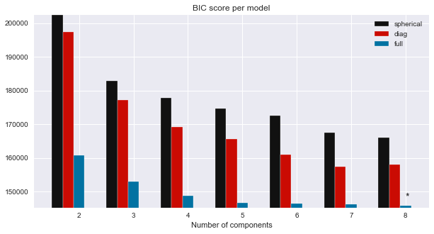

```python
# this code has been manipulated from the source available on sklearn's website documentation
# plot the BIC
bic = np.array(bic)
color_iter = itertools.cycle(['k', 'r', 'b', 'g', 'c', 'm', 'y'])
clf = best_gmm
bars = []

plt.figure(figsize=(10,5))
spl = plt.subplot(1,1,1)
# Plot the BIC scores
for i, (cv_type, color) in enumerate(zip(cv_types, color_iter)):
    xpos = np.array(n_components_range) + .2 * (i - 2)
    bars.append(plt.bar(xpos, bic[i * len(n_components_range):
                                  (i + 1) * len(n_components_range)],
                        width=.2, color=color))
plt.xticks(n_components_range)
plt.ylim([bic.min() * 1.01 - .01 * bic.max(), bic.max()])
plt.title('BIC score per model')

xpos = np.min(n_components_range)-0.4 + np.mod(bic.argmin(), len(n_components_range)) +\
    .2 * np.floor(bic.argmin() / len(n_components_range))
plt.text(xpos, bic.min() * 0.97 + .03 * bic.max(), '*', fontsize=14)
spl.set_xlabel('Number of components')
spl.legend([b[0] for b in bars], cv_types)

plt.show()
```

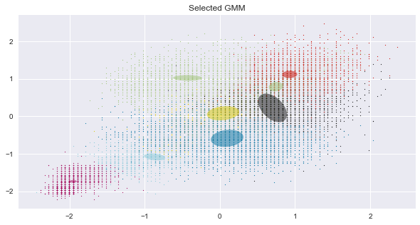

```python
# this code has been manipulated from the source available on sklearn's website documentation
# Plot the winner
plt.figure(figsize=(10,5))
splot = plt.subplot(1,1,1)
Y_ = clf.predict(X)
for i, (mean, covar, color) in enumerate(zip(clf.means_, clf.covariances_,
                                             color_iter)):
    if len(covar.shape)<2:
        tmp = np.zeros((2,2))
        np.fill_diagonal(tmp,covar)
        covar = tmp
    elif covar.shape[0] != covar.shape[1]:
        covar = np.diag(covar)

    v, w = linalg.eigh(covar)
    if not np.any(Y_ == i):
        continue
    plt.scatter(X[Y_ == i, 0], X[Y_ == i, 1], .8, color=color)

    # Plot an ellipse to show the Gaussian component
    angle = np.arctan2(w[0][1], w[0][0])
    angle = 180 * angle / np.pi  # convert to degrees
    v *= 4
    ell = mpl.patches.Ellipse(mean, v[0], v[1], 180 + angle, color=color)
    ell.set_clip_box(splot.bbox)
    ell.set_alpha(.5)
    splot.add_artist(ell)


plt.title('Selected GMM')
plt.show()
```

### Spectral Clustering

In spectral clustering, the data points are treated as nodes of a graph. The method has become one of the most popular modern clustering algorithms. It uses information from the eigenvalues (spectrum) of special matrices (Affinity matrix, degree matrix, Laplacian matrix) derived from the graph or the data set.

#### (1) affinity = 'nearest_neighbors'

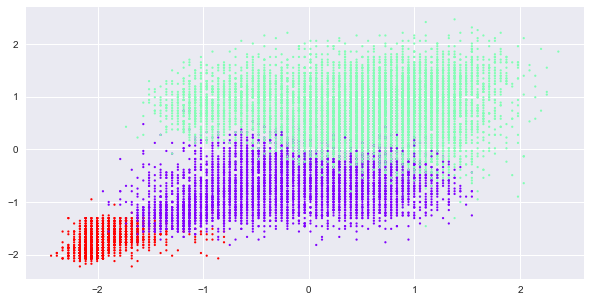

```python
from sklearn.cluster import SpectralClustering
nclust = 3

# If a string, this may be one of ‘nearest_neighbors’, ‘precomputed’, ‘rbf’
#  or one of the kernels supported by sklearn.metrics.pairwise_kernels
spc = SpectralClustering(n_clusters=nclust, affinity = 'nearest_neighbors')
labels = spc.fit_predict(X)

plt.figure(figsize=(10,5))
plt.scatter(X[:, 0], X[:, 1], c=labels,cmap=plt.cm.rainbow, s=5, linewidths=0)
plt.show()
```

#### (2) affinity = 'precomputed'

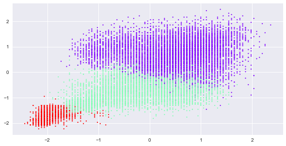

```python
from sklearn.cluster import SpectralClustering
from sklearn.neighbors import kneighbors_graph

nclust = 3
Xknn = kneighbors_graph(X, 10)

spc = SpectralClustering(n_clusters=nclust, affinity = 'precomputed')
labels = spc.fit_predict(Xknn)

plt.figure(figsize=(10,5))
plt.scatter(X[:, 0], X[:, 1], c=labels,cmap=plt.cm.rainbow, s=5, linewidths=0)
plt.show()
```

The clusters produced by 'nearest_neighbors' and 'precomputed' look very similar.

⏫ Table of Contents

# 6. Modeling and Evaluation 3: Visualize Results

### Linear Regression Performance Comparison: w/ vs. w/o Clustering

#### a) Using 5 attacking attributes w/o clustering

```
Best parameters set found:
{'fit_intercept': True, 'normalize': False}

Mean score summary of each gridsearch estimator executed
```

[figure not shown]

```
10 fold cross validation average scores of the best Estimator found by GridSearchCV

The average MAE for all cv folds is: 			 4416.6
The average MAE percentage (MAPE) for all cv folds is: 	 99.921
The average RMSE for all cv folds is: 			 9919.0
The average R2 for all cv folds is: 			 0.76118
Cross Validation Fold Mean Error Scores
           MAE        MAPE          RMSE        R2
0  4098.359489   98.726065   8581.261455  0.772731
1  4685.746260   99.973303  11072.603042  0.753215
2  3922.489710   98.226646   8411.785365  0.726033
3  4614.297659  109.343173  11063.455135  0.762239
4  4372.485514  105.662612   9507.122868  0.719193
5  4409.979913  100.429447   9487.563796  0.827837
6  4410.891615  101.677825   9503.267695  0.778887
7  4576.155879   89.632866  10226.837357  0.748977
8  4484.167756   97.134626   9673.490120  0.789402
9  4591.753411   98.404383  11662.612173  0.733252
```

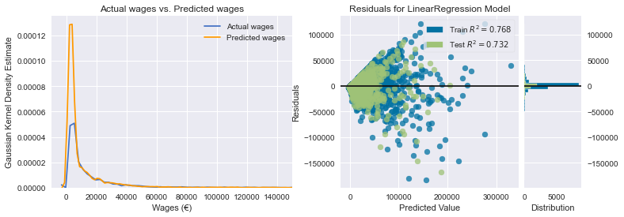

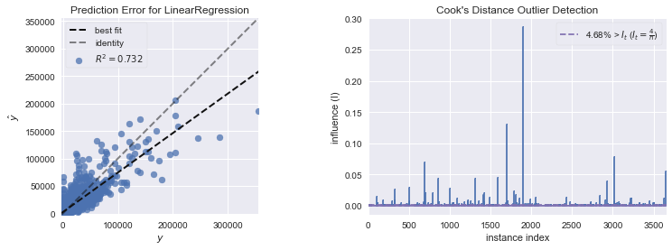

```
CPU times: user 24.4 s, sys: 2.78 s, total: 27.1 s
Wall time: 7.21 s
```

```python
%%time
import warnings
warnings.filterwarnings('ignore')

from sklearn.linear_model import LinearRegression

linreg = LinearRegression()
parameters = {'normalize':(True,False), 'fit_intercept':(True,False)}

m = evaluate_reg_model_performance('Linear Reg',parameters,linreg,'RMSE',X_reg_train,y_reg_train,X_reg_test,y_reg_test,nCV=10)
model_reg_stats = model_reg_stats.append(m[0])
#model_reg_yhat = model_reg_yhat.append(m[1])
```

#### b) Using new created attacking cluster attribute

```
Best parameters set found:
{'fit_intercept': True, 'normalize': False}

Mean score summary of each gridsearch estimator executed
```

[figure not shown]

```
10 fold cross validation average scores of the best Estimator found by GridSearchCV

The average MAE for all cv folds is: 			 4422.1
The average MAE percentage (MAPE) for all cv folds is: 	 100.11
The average RMSE for all cv folds is: 			 9912.9
The average R2 for all cv folds is: 			 0.76146
Cross Validation Fold Mean Error Scores
           MAE        MAPE          RMSE        R2
0  4110.551883   98.617089   8587.259065  0.772414
1  4692.031659   99.749353  11075.513038  0.753085
2  3936.471460   98.344187   8409.806679  0.726162
3  4615.476797  109.456841  11046.937864  0.762948
4  4376.705888  106.499937   9499.884240  0.719621
5  4416.958273  100.563705   9480.986059  0.828075
6  4427.817770  102.239048   9500.653461  0.779009
7  4568.659174   89.876335  10208.949874  0.749854
8  4487.448159   97.154179   9659.694711  0.790002
9  4588.990090   98.554241  11658.923777  0.733421
CPU times: user 17.1 s, sys: 2.41 s, total: 19.5 s
Wall time: 2.24 s
```

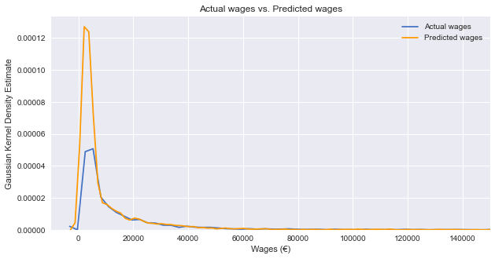

```python
%%time
import warnings
warnings.filterwarnings('ignore')

from sklearn.linear_model import LinearRegression

linreg = LinearRegression()
parameters = {'normalize':(True,False), 'fit_intercept':(True,False)}

m = evaluate_reg_model_performance('Linear Reg-Clustered',parameters,linreg,'RMSE',X_reg_cls_train,y_reg_cls_train,X_reg_cls_test,y_reg_cls_test,nCV=10)
model_reg_stats = model_reg_stats.append(m[0])
#model_reg_yhat = model_reg_yhat.append(m[1])
```

### Elastic Net Regression Performance Comparison: w/ vs. w/o Clustering

#### a) Using 5 attacking attributes w/o clustering

```
Best parameters set found:
{'alpha': 0.1, 'l1_ratio': 1, 'selection': 'cyclic', 'warm_start': True}

Mean score summary of each gridsearch estimator executed
```

[figure not shown]

```
10 fold cross validation average scores of the best Estimator found by GridSearchCV

The average MAE for all cv folds is: 			 4385.8
The average MAE percentage (MAPE) for all cv folds is: 	 97.967
The average RMSE for all cv folds is: 			 9916.9
The average R2 for all cv folds is: 			 0.76127
Cross Validation Fold Mean Error Scores
           MAE        MAPE          RMSE        R2
0  4072.485542   97.032897   8581.440151  0.772722
1  4656.643239   97.998602  11063.885963  0.753603
2  3896.549446   96.422252   8417.011093  0.725693
3  4583.224804  107.591592  11065.380608  0.762156
4  4331.169610  103.105043   9490.906427  0.720150
5  4378.801318   98.427827   9478.440533  0.828167
6  4375.039173   99.310920   9506.573769  0.778733
7  4549.558068   88.232205  10227.643063  0.748937
8  4448.591612   94.988311   9668.982907  0.789598
9  4565.855218   96.565313  11668.424758  0.732986
CPU times: user 11.7 s, sys: 1.05 s, total: 12.7 s
Wall time: 2.52 s
```

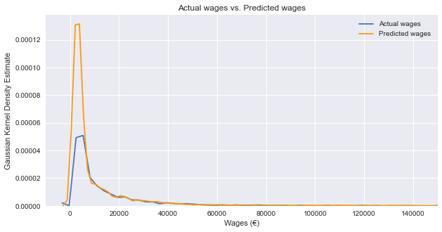

```python
%%time
from sklearn.linear_model import ElasticNet

reg = ElasticNet(fit_intercept=True, normalize=True, precompute=True, copy_X=True
          , max_iter=10000, tol=0.0001, random_state=45)

#Test parameters
l1_ratio = [0.5, 0.75, 1]
alpha = [0.001, 0.1]
selection = ['cyclic','random']
warm_start = [True]
parameters = {'l1_ratio': l1_ratio, 'alpha': alpha, 'selection': selection, 'warm_start': warm_start}

m = evaluate_reg_model_performance('Elastic Net Reg',parameters,reg,'RMSE',X_reg_train,y_reg_train,X_reg_test,y_reg_test,nCV=10)
model_reg_stats = model_reg_stats.append(m[0])
#model_reg_yhat['Elastic Net Reg'] = m[1].copy()
```

#### b) Using new created attacking cluster attribute

```
Best parameters set found:
{'alpha': 0.1, 'l1_ratio': 1, 'selection': 'random', 'warm_start': True}

Mean score summary of each gridsearch estimator executed
```

[figure not shown]

```
10 fold cross validation average scores of the best Estimator found by GridSearchCV

The average MAE for all cv folds is: 			 4389.0
The average MAE percentage (MAPE) for all cv folds is: 	 97.982
The average RMSE for all cv folds is: 			 9912.1
The average R2 for all cv folds is: 			 0.76149
Cross Validation Fold Mean Error Scores
           MAE        MAPE          RMSE        R2
0  4081.071271   96.735582   8586.685668  0.772444
1  4661.661544   97.766677  11065.834733  0.753516
2  3907.515822   96.385474   8416.108564  0.725751
3  4581.999246  107.440599  11051.371625  0.762758
4  4334.196231  103.780195   9484.699033  0.720516
5  4384.237171   98.465809   9473.839931  0.828334
6  4385.442413   99.602700   9504.050496  0.778851
7  4539.965862   88.104397  10213.403106  0.749636
8  4451.682086   94.946232   9657.477903  0.790098
9  4562.074860   96.587908  11667.495420  0.733029
CPU times: user 12.8 s, sys: 1.2 s, total: 14.1 s
Wall time: 2.76 s
```

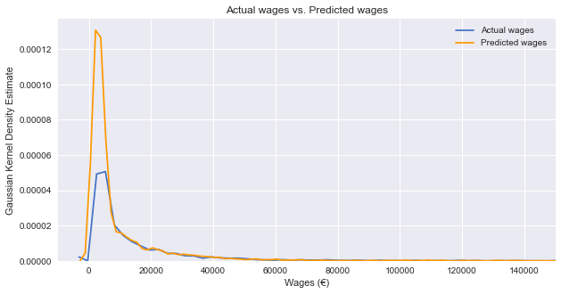

```python
%%time
from sklearn.linear_model import ElasticNet

reg = ElasticNet(fit_intercept=True, normalize=True, precompute=True, copy_X=True
          , max_iter=10000, tol=0.0001, random_state=45)

#Test parameters
l1_ratio = [0.5, 0.75, 1]
alpha = [0.001, 0.1]
selection = ['cyclic','random']
warm_start = [True]
parameters = {'l1_ratio': l1_ratio, 'alpha': alpha, 'selection': selection, 'warm_start': warm_start}

m = evaluate_reg_model_performance('Elastic Net-Clustered',parameters,reg,'RMSE',X_reg_cls_train,y_reg_cls_train,X_reg_cls_test,y_reg_cls_test,nCV=10)
model_reg_stats = model_reg_stats.append(m[0])
#model_reg_yhat['Elastic Net Reg'] = m[1].copy()
```